# Session 1 — Counts, Rates and the Poisson Idea

Counts vs rates · person-time · mean and variance · zeros · trend and season · Lab 1

Community Medicine Workshop

## Where we are

- Regression workshop: continuous outcomes (linear) and yes/no outcomes (logistic)
- Today: the outcome is a **count of events**: cases per ward per month, admissions per day, deaths per year
- By the end you can:
  - tell a **count** from a **rate**, and name the right **denominator**
  - compute **incidence rates** and **rate ratios** from a table
  - describe the **Poisson** idea and check **mean vs variance**
  - spot **zeros**, **trend** and **seasonality**

## Our data: dengue in a city

- **30 wards** x **36 months** (2023-2025) = 1,080 ward-months
- `cases` notified, ward `population`, `slum` ward, `rain_mm`, **fogging** (vector control) in half the wards from month 25
- Invented, but built to behave like real surveillance data

```r
dg |> select(ward, date, population, slum, cases, rain_lag1, fogging) |> head(6)
```

```
# A tibble: 6 × 7
  ward  date       population slum     cases rain_lag1 fogging
  <fct> <date>          <dbl> <fct>    <dbl>     <dbl> <fct>
1 W01   2023-01-01      11300 Non-slum     2        90 No
2 W01   2023-01-31      11300 Non-slum     0         0 No
3 W01   2023-03-03      11300 Non-slum     2         0 No
4 W01   2023-04-02      11300 Non-slum     4        33 No
5 W01   2023-05-03      11300 Non-slum     5        57 No
6 W01   2023-06-02      11300 Non-slum     4       190 No
```

# Topic 1 — Counts and rates

## A count is not a rate

- **Count:** how many events (cases)
- **Rate:** events per unit of **person-time at risk**: cases / (people x time)
- A ward of 60,000 will have more cases than a ward of 8,000 **even at the same risk**
- **Compare rates, not counts**, unless you only want workload

```r
c(cases = sum(dg$cases), rate_per_100k_person_months = round(sum(dg$cases) / sum(dg$population) * 1e5, 1))
```

```
                      cases rate_per_100k_person_months
                    10411.0                        34.3
```

```r
dg |> group_by(slum) |> summarise(cases = sum(cases), person_months = sum(population), rate_per_100k = round(cases / person_months * 1e5, 1))
```

```
# A tibble: 2 × 4
  slum     cases person_months rate_per_100k
  <fct>    <dbl>         <dbl>         <dbl>
1 Non-slum  4312      16516800          26.1
2 Slum      6099      13870800          44
```

## Person-time and the rate ratio

**Person-time** is the denominator: each ward-month contributes its population x 1 month. The slum **rate ratio** is about 1.7.

# Topic 2 — The Poisson distribution

## Counts of rare, independent events

P(Y = k) = e<sup>-mu</sup> mu<sup>k</sup> / k! with **mean = variance = mu**

- Events occur **independently**, at a **constant rate**, and one at a time
- The single parameter **mu** is both the **mean** and the **variance**
- Skewed for small mu, nearly symmetric for large mu
- Poisson regression (Session 2) models log(mu) as a linear function of predictors

```r
bind_rows(tibble(k = 0:25, p = dpois(0:25, 2), mu = "mean 2"), tibble(k = 0:25, p = dpois(0:25, 10), mu = "mean 10")) |>
  ggplot(aes(k, p, fill = mu)) + geom_col(position = "dodge") + labs(x = "Count", y = "Probability", fill = NULL)
```

## Counts of rare, independent events

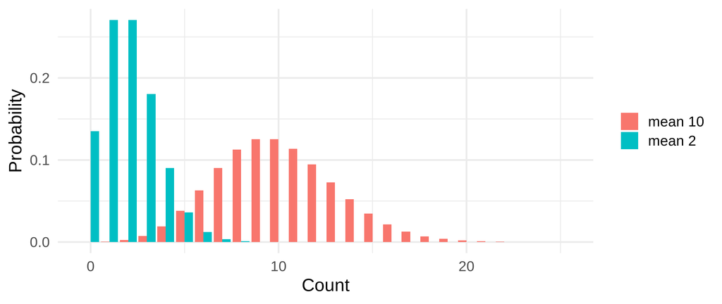

## Does our data look Poisson?

```r
c(mean = round(mean(dg$cases), 1), variance = round(var(dg$cases), 0))
```

```
    mean variance
     9.6    394.0
```

```r
c(observed_zeros = round(mean(dg$cases == 0), 3), poisson_expected_zeros = signif(dpois(0, mean(dg$cases)), 2))
```

```
        observed_zeros poisson_expected_zeros
              0.202000               0.000065
```

The **variance is about 41 times the mean**, and there are far more **zeros** than a Poisson allows. This is **overdispersion** (Session 3) and **excess zeros** (Session 4). Part of it is just **different wards, seasons and rates mixed together**, which regression can explain.

# Topic 3 — Look before you model

## Trend and seasonality

```r
dg |> group_by(date) |> summarise(cases = sum(cases)) |> ggplot(aes(date, cases)) + geom_line(colour = col_navy) + geom_point() +
  labs(x = NULL, y = "Cases in the city per month")
```

- A clear **monsoon peak** every year, and a mild upward drift
- Model it: **month** (sine and cosine, or `factor(month)`) and a **time trend**
- Ignoring season confounds comparisons: fogging started in **month 25**, after growth

## Trend and seasonality

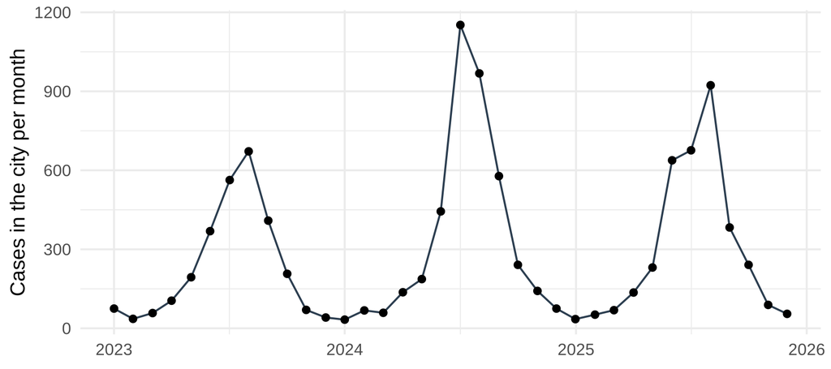

## Checklist before modelling counts

1. Define the **event**, the **unit** (ward-month) and the **denominator** (person-time)
2. Plot the **distribution** (zeros? skew?) and the **time series**
3. Compare **mean and variance** by group
4. List the **exposures**, **confounders** (season, trend, ward type) and **clustering** (the same ward is measured 36 times)

## 🔧 Switch to R — Lab 1

**File:** `counts-workshop/labs/lab1_counts.R`

- totals, crude rates and a rate ratio by hand
- mean vs variance, histogram, zeros against a Poisson
- the city time series

**Time:** 30 minutes · answer the Q questions in the comments

## Self-check quiz (1/5)

Ward A (60,000 people) reports 90 cases in a month and ward B (10,000 people) reports 25. Which statement is correct?

- Ward A has the higher rate because it has more cases
- The two wards have the same rate in the month
- Ward B has the higher rate, 250 vs 150 per 100,000
- Rates cannot be calculated from one month of data

## Self-check quiz (2/5)

What is the denominator of an incidence rate?

- The number of wards
- Person-time at risk
- The number of cases
- The number of months in the study

## Self-check quiz (3/5)

A Poisson distribution has mean 4. What is its variance?

- 2, the square root of the mean
- 16, the square of the mean
- 4, the same as the mean
- It cannot be determined without the data

## Self-check quiz (4/5)

Monthly case counts have mean 9.6 and variance 394. What does this suggest?

- A perfect Poisson process, in which variance and mean coincide
- A fault in the dates in the file, which should be corrected first
- That the counts are too small for any model to be fitted to them
- Overdispersion: more variation than a Poisson process would allow

## Self-check quiz (5/5)

Why does a plot of cases against time matter before modelling?

- It shows season and trend that could confound the comparison
- It gives the p-value for the effect of the intervention directly
- It removes the need for a denominator in the rate calculation
- It proves that the events in the data set occur independently

## Score and take-home

**Your score:**

- A **count** is not a **rate**: divide by **person-time**
- Poisson: **mean = variance**; check it
- Look for **zeros, skew, trend and season** before modelling
- **Rate ratio** = rate in one group / rate in another

**Next:** Session 2: Poisson regression